# DSI_Data_Challenge_5

Dingxin Lu

11/29/2021

[My Github link] https://github.com/sydneydlu98/DSI_Data_Challenge_5

# Loading/Cleaning Data and Exploratory Analysis

In this Data Challenge, we will be clustering foods from the nndb_flat dataset provided on Canvas. To load/clean the data as well as perform some exploratory analysis:

1. Read in the data

```r
## load all the packages
library(readr)
library(dplyr)
library(GGally)
library(tidyverse)

## read in data
data <- read_csv("nndb_flat.csv")
```

2. We will be dealing with only data that falls under the food groups of Vegetables and Vegetable Products, Beef Products, and Sweets. Filter the data to contain only these food groups.

```r
## filter the data to only contain food groups of Vegetables and Vegetable Products, Beef Products, and Sweets
object <- c("Sweets", "Beef Products", "Vegetables and Vegetable Products")

clean_data <- data %>%
  subset(FoodGroup == object)
```

3. Select only the variables from Energy_kcal to Zinc_mg

```r
var <- clean_data %>%
  select(Energy_kcal:Zinc_mg)
```

4. Examine the correlation among the variables using GGally::ggcorr. Which variables have a high correlation?

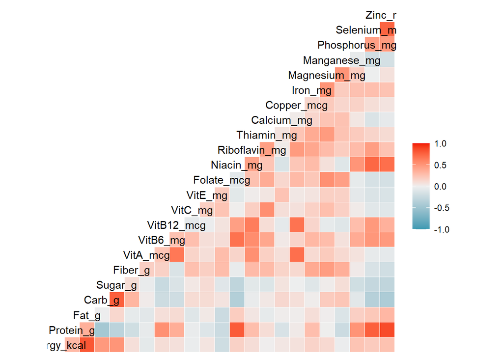

```r
GGally::ggcorr(var)
```